# Assignment 2: Spatial Analysis and Visualization

## Part 3: Bring Your Own Data Analysis

Choose your own additional spatial dataset and conduct a supplementary analysis.

### Challenge Options

Choose ONE of the following challenge exercises, or propose your own research question using OpenDataPhilly data (https://opendataphilly.org/datasets/).

**Note these are just loose suggestions to spark ideas - follow or make your own as the data permits and as your ideas evolve. This analysis should include bringing in your own dataset, ensuring the projection/CRS of your layers align and are appropriate for the analysis (not lat/long or geodetic coordinate systems). The analysis portion should include some combination of spatial and attribute operations to answer a relatively straightforward question**

#### Education & Youth Services

**Option A: Educational Desert Analysis**

- **Data:** Schools, Libraries, Recreation Centers, Census tracts (child population)
- **Question:** “Which neighborhoods lack adequate educational infrastructure for children?”
- **Operations:** Buffer schools/libraries (0.5 mile walking distance), identify coverage gaps, overlay with child population density
- **Policy relevance:** School district planning, library placement, after-school program siting

**Option B: School Safety Zones**

- **Data:** Schools, Crime Incidents, Bike Network
- **Question:** “Are school zones safe for walking/biking, or are they crime hotspots?”
- **Operations:** Buffer schools (1000ft safety zone), spatial join with crime incidents, assess bike infrastructure coverage
- **Policy relevance:** Safe Routes to School programs, crossing guard placement

#### Environmental Justice

**Option C: Green Space Equity**

- **Data:** Parks, Street Trees, Census tracts (race/income demographics)
- **Question:** “Do low-income and minority neighborhoods have equitable access to green space?”
- **Operations:** Buffer parks (10-minute walk = 0.5 mile), calculate tree canopy or park acreage per capita, compare by demographics

## **Policy relevance:** Climate resilience, environmental justice, urban forestry investment

#### Public Safety & Justice

**Option D: Crime & Community Resources**

- **Data:** Crime Incidents, Recreation Centers, Libraries, Street Lights
- **Question:** “Are high-crime areas underserved by community resources?”
- **Operations:** Aggregate crime counts to census tracts or neighborhoods, count community resources per area, spatial correlation analysis
- **Policy relevance:** Community investment, violence prevention strategies

#### Infrastructure & Services

**Option E: Polling Place Accessibility**

- **Data:** Polling Places, SEPTA stops, Census tracts (elderly population, disability rates)
- **Question:** “Are polling places accessible for elderly and disabled voters?”
- **Operations:** Buffer polling places and transit stops, identify vulnerable populations, find areas lacking access
- **Policy relevance:** Voting rights, election infrastructure, ADA compliance

#### Health & Wellness

**Option F: Recreation & Population Health**

- **Data:** Recreation Centers, Playgrounds, Parks, Census tracts (demographics)
- **Question:** “Is lack of recreation access associated with vulnerable populations?”
- **Operations:** Calculate recreation facilities per capita by neighborhood, buffer facilities for walking access, overlay with demographic indicators
- **Policy relevance:** Public health investment, recreation programming, obesity prevention

#### Emergency Services

**Option G: EMS Response Coverage**

- **Data:** Fire Stations, EMS stations, Population density, High-rise buildings
- **Question:** “Are population-dense areas adequately covered by emergency services?”
- **Operations:** Create service area buffers (5-minute drive = ~2 miles), assess population coverage, identify gaps in high-density areas
- **Policy relevance:** Emergency preparedness, station siting decisions

#### Arts & Culture

**Option H: Cultural Asset Distribution**

- **Data:** Public Art, Museums, Historic sites/markers, Neighborhoods
- **Question:** “Do all neighborhoods have equitable access to cultural amenities?”
- **Operations:** Count cultural assets per neighborhood, normalize by population, compare distribution across demographic groups
- **Policy relevance:** Cultural equity, tourism, quality of life, neighborhood identity

### Data Sources

**OpenDataPhilly:** https://opendataphilly.org/datasets/ - Most datasets available as GeoJSON, Shapefile, or CSV with coordinates - Always check the Metadata for a data dictionary of the fields.

**Additional Sources:**

- **Pennsylvania Open Data:** https://data.pa.gov/
- **Census Bureau (via tidycensus):** Demographics, economic indicators, commute patterns
- **TIGER/Line (via tigris):** Geographic boundaries

### Recommended Starting Points

**If you’re feeling confident:** Choose an advanced challenge with multiple data layers. **If you are a beginner, choose something more manageable that helps you understand the basics**

**If you have a different idea:** Propose your own question! Just make sure:

- You can access the spatial data
- You can perform at least 2 spatial operations

### Your Analysis

**Your Task:**

1. **Find and load additional data**
   - Document your data source
   - Check and standardize the CRS
   - Provide basic summary statistics

```r
# Load your additional dataset

parks <- st_read("data/PPR_Program_Sites.geojson")
```

**Questions to answer:**

- What dataset did you choose and why?

[Dataset chosen: Philadelphia Parks & Recreation Program Sites]

Reason for choice: [This dataset was selected to analyze green space accessibility and recreation equity in Philadelphia. It represents public parks and recreation facilities which is a key indicator of environmental and community well-being. By examining their spatial distribution relative to neighborhood demographics, we can assess whether low-income communities have equitable access to recreational opportunities.]

- What is the data source and date?

[Data were obtained from OpenDataPhilly – PPR Program Sites, published and maintained by Philadelphia Parks & Recreation. The dataset was accessed and downloaded in October 2025.]

- How many features does it contain?

[- Number of features: 171 program sites - Geometry type: Point - Coordinate Reference System (CRS): WGS 84 (EPSG:4326) - Extent: Longitude -75.2563 to -74.9694, Latitude 39.9044 to 40.1228]

- What CRS is it in? Did you need to transform it?

[The dataset was originally in WGS 84 (geographic coordinates), which is not ideal for distance-based analysis. It was reprojected to EPSG:5070 (NAD83 / Conus Albers) for accurate spatial measurement and buffering operations.]

```r
parks <- st_transform(parks, 5070)
```

2. **Pose a research question**

Write a clear research statement that your analysis will answer.

**Examples:**

- “Do vulnerable tracts have adequate public transit access to hospitals?”
- “Are EMS stations appropriately located near vulnerable populations?”
- “Do areas with low vehicle access have worse hospital access?”

**Research Question**:

Do low-income neighborhoods in Philadelphia have less access to parks and recreation facilities compared to higher-income areas?

Explanation:

This question investigates whether green space accessibility is distributed equitably across socioeconomic groups in Philadelphia. By analyzing the spatial relationship between parks and recreation sites and census tract median income, this study aims to identify whether environmental and recreational resources are disproportionately concentrated in wealthier neighborhoods which is an important issue for urban equity and public health planning. —

3. **Conduct spatial analysis**

Use at least TWO spatial operations to answer your research question.

**Required operations (choose 2+):**

- Buffers
- Spatial joins
- Spatial filtering with predicates
- Distance calculations
- Intersections or unions
- Point-in-polygon aggregation

**Your Task:**

```r
library(viridis)
```

```r
# Your spatial analysis

philly_tracts <- get_acs(
  geography = "tract",
  state     = "PA",
  county    = "Philadelphia",
  variables = c(total_pop = "B01003_001", medhhinc = "B19013_001"),
  geometry  = TRUE,
  output    = "wide",
  year      = 2023,
  survey    = "acs5"
) %>%
  transmute(
    GEOID,
    total_pop = total_popE,
    medhhinc  = medhhincE,
    geometry
  )

target_crs <- 5070

parks_5070  <- st_transform(parks,         target_crs)
tracts_5070 <- st_transform(philly_tracts, target_crs)

parks_buf <- st_buffer(parks_5070, dist = 800)
tract_cent <- st_centroid(tracts_5070)

tract_access <- tract_cent %>%
  mutate(has_park_access = lengths(st_intersects(., parks_buf)) > 0) %>%

  st_drop_geometry() %>%
  select(GEOID, has_park_access)

tracts_5070 <- tracts_5070 %>%
  left_join(tract_access, by = "GEOID")

parks_in_tract <- st_join(tracts_5070, parks_5070, join = st_contains) %>%
  st_drop_geometry() %>%
  count(GEOID, name = "n_parks")

tracts_5070 <- tracts_5070 %>%
  left_join(parks_in_tract, by = "GEOID") %>%
  mutate(n_parks = ifelse(is.na(n_parks), 0L, n_parks))

city_median_income <- median(tracts_5070$medhhinc, na.rm = TRUE)

tracts_5070 <- tracts_5070 %>%
  mutate(income_group = ifelse(medhhinc < city_median_income, "Low income", "High income"))

access_summary <- tracts_5070 %>%
  st_drop_geometry() %>%
  group_by(income_group) %>%
  summarise(
    n_tracts     = n(),
    access_rate  = mean(has_park_access, na.rm = TRUE),
    mean_parks   = mean(n_parks, na.rm = TRUE),
    .groups = "drop"
  )

access_summary
```

```
# A tibble: 3 × 4
  income_group n_tracts access_rate mean_parks
  <chr>           <int>       <dbl>      <dbl>
1 High income       191       0.717       1.06
2 Low income        190       0.847       1.07
3 <NA>               27       0.370       1.15
```

```r
citywide <- tracts_5070 %>%
  st_drop_geometry() %>%
  summarise(
    tracts_with_access    = sum(has_park_access, na.rm = TRUE),
    tracts_without_access = sum(!has_park_access, na.rm = TRUE),
    access_rate_city      = mean(has_park_access, na.rm = TRUE)
  )

citywide
```

```
  tracts_with_access tracts_without_access access_rate_city
1                308                   100         0.754902
```

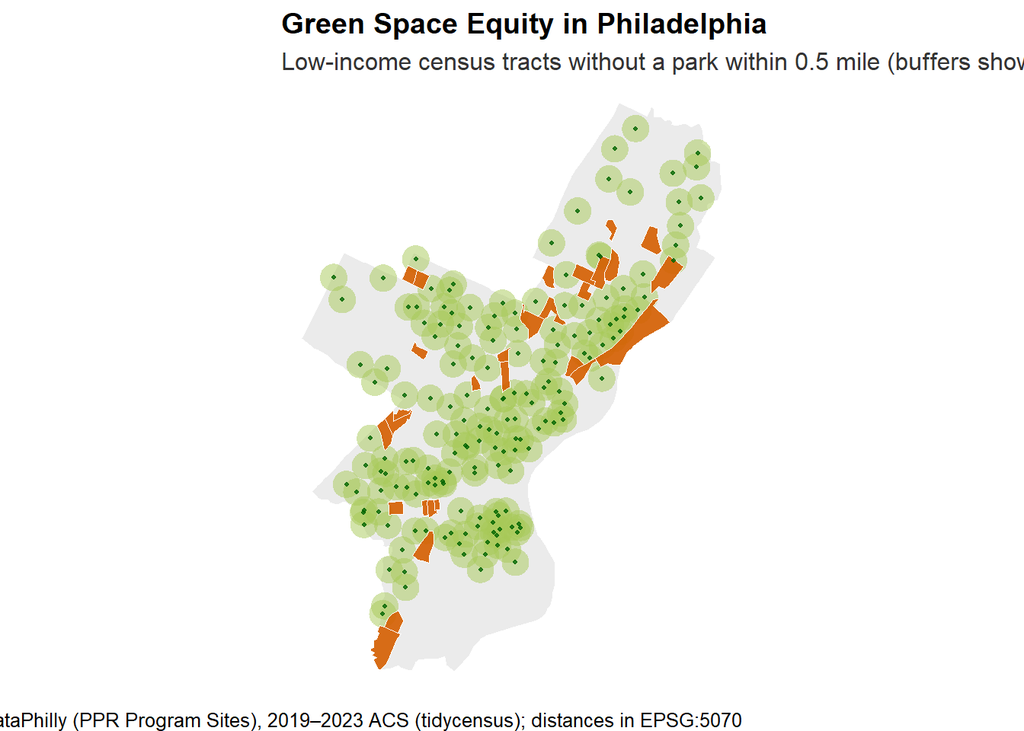

```r
ggplot() +
  geom_sf(data = tracts_5070, fill = "grey92", color = NA) +
  geom_sf(data = parks_buf, fill = "#A7C957", color = NA, alpha = 0.5) +
  geom_sf(
    data = tracts_5070 %>% filter(income_group == "Low income", !has_park_access),
    fill = "#D55E00", color = "white", linewidth = 0.15, alpha = 0.9
  ) +

  geom_sf(data = parks_5070, color = "darkgreen", size = 0.8, alpha = 0.8) +
  labs(
    title = "Green Space Equity in Philadelphia",
    subtitle = "Low-income census tracts without a park within 0.5 mile (buffers shown in green)",
    caption = "Sources: OpenDataPhilly (PPR Program Sites), 2019–2023 ACS (tidycensus); distances in EPSG:5070"
  ) +
  theme_void(base_size = 12) +
  theme(
    plot.title = element_text(face = "bold"),
    plot.subtitle = element_text(color = "grey20")
  )
```

**Analysis requirements:**

- Clear code comments explaining each step
- Appropriate CRS transformations
- Summary statistics or counts
- At least one map showing your findings
- Brief interpretation of results (3-5 sentences)

## Finally - A few comments about your incorporation of feedback!

Take a few moments to clean up your markdown document and then write a line or two or three about how you may have incorporated feedback that you recieved after your first assignment.

Comments:

## Submission Requirements

**What to submit:**

1. **Rendered HTML document posted to your course portfolio** with all code, outputs, maps, and text
   - Use `embed-resources: true` in YAML so it’s a single file
   - All code should run without errors
   - All maps and charts should display correctly

**File naming:** `LastName_FirstName_Assignment2.html` and `LastName_FirstName_Assignment2.qmd`